# Employee Retention

## Data

Let’s read the dataset and see the variables we have

### R

```r
#read file
data=read.csv("employee_retention_data.csv")

head(data)
```

```
  employee_id company_id             dept seniority salary  join_date  quit_date
1       13021          7 customer_service        28  89000 2014-03-24 2015-10-30
2      825355          7        marketing        20 183000 2013-04-29 2014-04-04
3      927315          4        marketing        14 101000 2014-10-13       <NA>
4      662910          7 customer_service        20 115000 2012-05-14 2013-06-07
5      256971          2     data_science        23 276000 2011-10-17 2014-08-22
6      509529          4     data_science        14 165000 2012-01-30 2013-08-30
```

### Python

```python
import pandas
import numpy as np
pandas.set_option('display.max_columns', 10)
pandas.set_option('display.width', 350)

#read file
data=pandas.read_csv("employee_retention_data.csv")

print(data.head())
```

```
   employee_id  company_id              dept  seniority    salary   join_date   quit_date
0      13021.0           7  customer_service         28   89000.0  2014-03-24  2015-10-30
1     825355.0           7         marketing         20  183000.0  2013-04-29  2014-04-04
2     927315.0           4         marketing         14  101000.0  2014-10-13         NaN
3     662910.0           7  customer_service         20  115000.0  2012-05-14  2013-06-07
4     256971.0           2      data_science         23  276000.0  2011-10-17  2014-08-22
```

## First Question Solution

Assume, for each company, that the headcount starts from zero on 2011/01/23. Estimate employee headcount, for each company on each day, from 2011/01/24 to 2015/12/13. That is, if by 2012/03/02 2000 people have joined company 1 and 1000 of them have already quit, then company headcount on 2012/03/02 for company 1 would be 1000. You should create a table with 3 columns: day, employee_headcount, company_id

### R

```r
#libraries needed
require(dplyr)
require(rpart)
require(ggplot2)
require(scales)

str(data) #check the structure
```

```
'data.frame':   24702 obs. of  7 variables:
 $ employee_id: num  13021 825355 927315 662910 256971 ...
 $ company_id : int  7 7 4 7 2 4 4 2 9 1 ...
 $ dept       : Factor w/ 6 levels "customer_service",..: 1 5 5 1 2 2 1 1 4 6 ...
 $ seniority  : int  28 20 14 20 23 14 21 4 7 7 ...
 $ salary     : num  89000 183000 101000 115000 276000 165000 107000 30000 160000 104000 ...
 $ join_date  : Factor w/ 995 levels "2011-01-24","2011-01-25",..: 643 459 758 264 148 205 558 633 380 280 ...
 $ quit_date  : Factor w/ 664 levels "2011-10-13","2011-10-14",..: 643 364 NA 229 428 267 NA NA 640 NA ...
```

```r
# these are categorical vars
data$company_id  = as.factor(data$company_id)
data$employee_id = as.factor(data$employee_id)

#make it a date
data$join_date = as.Date(data$join_date)
data$quit_date = as.Date(data$quit_date)

#everything seems to make sense, some simple plots would help double check that
#summary for continuous variables/dates
summary(data[,c(4:7)])
```

```
   seniority         salary         join_date            quit_date
 Min.   : 1.00   Min.   : 17000   Min.   :2011-01-24   Min.   :2011-10-13
 1st Qu.: 7.00   1st Qu.: 79000   1st Qu.:2012-04-09   1st Qu.:2013-06-28
 Median :14.00   Median :123000   Median :2013-06-24   Median :2014-06-20
 Mean   :14.13   Mean   :138183   Mean   :2013-06-29   Mean   :2014-05-02
 3rd Qu.:21.00   3rd Qu.:187000   3rd Qu.:2014-09-17   3rd Qu.:2015-03-27
 Max.   :99.00   Max.   :408000   Max.   :2015-12-10   Max.   :2015-12-09
                                                       NA's   :11192
```

```r
#summary for categorical variabless
summary(data[,-c(4:7)])
```

```
  employee_id      company_id                 dept
 36     :    1   1      :8486   customer_service:9180
 70     :    1   2      :4222   data_science    :3190
 107    :    1   3      :2749   design          :1380
 155    :    1   4      :2062   engineer        :4613
 157    :    1   5      :1755   marketing       :3167
 163    :    1   6      :1291   sales           :3172
 (Other):24696   (Other):4137
```

Let’s answer this question: You should create a table with 3 columns: day, employee_headcount, company_id.

```r
#create list of unique dates for the tables
unique_dates = seq(as.Date("2011/01/24"), as.Date("2015/12/13"), by = "day")

#create list of unique companies
unique_companies = unique(data$company_id)

#cross join so I get all combinations of dates and companies. Will need it later.
data_headcount = merge(unique_dates, unique_companies, by = NULL)
colnames(data_headcount) = c("date", "company_id")

#now I get for each day/company, how many people quit/got hired on that day
data_join = data %>%
            group_by(join_date, company_id) %>%
            summarise(join_count = length(join_date))

data_quit = data %>%
            group_by(quit_date, company_id) %>%
            summarise(quit_count = length(quit_date))

#Now I left outer join with data_headcount.
#NA means no people were hired/quit on that day cause there is no match.

data_headcount = merge (data_headcount, data_join,
                        by.x = c("date", "company_id"),
                        by.y = c("join_date", "company_id"),
                        all.x = TRUE)

data_headcount = merge (data_headcount, data_quit,
                        by.x = c("date", "company_id"),
                        by.y = c("quit_date", "company_id"),
                        all.x = TRUE)

#replace the NAs with 0
data_headcount$join_count[is.na(data_headcount$join_count)] = 0
data_headcount$quit_count[is.na(data_headcount$quit_count)] = 0

#Now I need the sum by company_id. Data set is already ordered by date, so I can simply use dplyr to group by company_id and do cumsum
data_headcount = data_headcount %>%
            group_by(company_id) %>%
            mutate ( join_cumsum = cumsum(join_count),
                     quit_cumsum = cumsum(quit_count)
                    )

# finally, for each date I just take join_count - quit_count and I am done
data_headcount$count = data_headcount$join_cumsum - data_headcount$quit_cumsum
data_headcount_table = data.frame(data_headcount[, c("date", "company_id","count")])

#Another way to do it would be with a for loop.  While you often hear that you should avoid for loops in R as much as possible, in some cases you don't care that much about processing time, and you are willing to have something slower but more understandable. Other data scientists reading your code in future (or even yourself) will appreciate.

#Let's try with the for loop. Again here we optimize for future readibility! This is as slow as it can possibly be, but much clearer.

#intialize empty vectors
loop_cumsum = c()
loop_date = c()
loop_company = c()
#loop through all days
for (i in seq(as.Date("2011/01/24"), as.Date("2015/12/13"), by = "day")) {
  # loop through all companies
   for (j in unique(data$company_id)){
        # count joins until that day
        tmp_join = nrow(subset(data, join_date <= i & company_id == j))
        # count quits
        tmp_quit = nrow(subset(data, quit_date <= i & company_id == j))
        loop_cumsum = c(loop_cumsum, tmp_join - tmp_quit )
        loop_date = c(loop_date, i)
        loop_company = c(loop_company, j)
   }
data_headcount_table_loop = data.frame(date = as.Date(loop_date, origin = '1970-01-01'), #fix R date
                                        company_id = loop_company,
                                        count = loop_cumsum)
}


#Let's finally check the two data sets are exactly the same:
all(data_headcount_table ==
    data_headcount_table_loop[order(data_headcount_table_loop[,1],
                                as.numeric(as.character(data_headcount_table_loop[,2]))
	                                   )
	                           ,]
	)
```

```
[1] TRUE
```

### Python

```python
from datetime import datetime

#make them a date
data['join_date'] = pandas.to_datetime(data['join_date'])
data['quit_date'] = pandas.to_datetime(data['quit_date'])

#everything seems to make sense, some simple plots would help double check that
data.describe(include="all")
```

| X | employee_id | company_id | dept | seniority | salary | join_date | quit_date |
| --- | --- | --- | --- | --- | --- | --- | --- |
| count | 24702.0 | 24702.000000 | 24702 | 24702.00000 | 24702.00 | 24702 | 13510 |
| unique | NA | NA | 6 | NA | NA | 995 | 664 |
| top | NA | NA | customer_service | NA | NA | 2012-01-03 00:00:00 | 2015-05-08 00:00:00 |
| freq | NA | NA | 9180 | NA | NA | 105 | 111 |
| first | NA | NA |  | NA | NA | 2011-01-24 00:00:00 | 2011-10-13 00:00:00 |
| last | NA | NA |  | NA | NA | 2015-12-10 00:00:00 | 2015-12-09 00:00:00 |
| mean | 501604.4 | 3.426969 |  | 14.12780 | 138183.35 |  |  |
| std | 288909.0 | 2.700011 |  | 8.08952 | 76058.18 |  |  |
| min | 36.0 | 1.000000 |  | 1.00000 | 17000.00 |  |  |
| 25% | 250133.8 | 1.000000 |  | 7.00000 | 79000.00 |  |  |
| 50% | 500793.0 | 2.000000 |  | 14.00000 | 123000.00 |  |  |
| 75% | 753137.2 | 5.000000 |  | 21.00000 | 187000.00 |  |  |
| max | 999969.0 | 12.000000 |  | 99.00000 | 408000.00 |  |  |

Let’s answer the question now. You should create a table with 3 columns: day, employee_headcount, company_id.

```python
#create list of unique dates for the tables
unique_dates = pandas.date_range(start='2011/01/24', end='2015/12/13')

#create list of unique companies
unique_companies = data['company_id'].unique()

#cross join so I get all combinations of dates and companies. Will need it later.
data_headcount = pandas.MultiIndex.from_product([unique_dates, unique_companies], names = ["date", "company_id"])
data_headcount = pandas.DataFrame(index = data_headcount).reset_index()

#now I get for each day/company, how many people quit/got hired on that day
data_join = data.groupby(['join_date', 'company_id']).size().reset_index(name='join_count')
data_join.columns.values[0]='date'
data_quit = data.groupby(['quit_date', 'company_id']).size().reset_index(name='quit_count')
data_quit.columns.values[0]='date'

#Now I left outer join with data_headcount.
#NA means no people were hired/quit on that day cause there is no match.
data_headcount = pandas.merge(data_headcount, data_join, on=["date", "company_id"], how='left')
data_headcount = pandas.merge(data_headcount, data_quit, on=["date", "company_id"], how='left')

#replace the NAs with 0
data_headcount.fillna(0, inplace=True)

#Now I need the sum by company_id. Data set is already ordered by date, so I can simply group by company_id and do cumsum
data_headcount['cumsum_join'] = data_headcount.groupby(['company_id'])['join_count'].apply(lambda x: x.cumsum())
data_headcount['cumsum_quit'] = data_headcount.groupby(['company_id'])['quit_count'].apply(lambda x: x.cumsum())

#finally, for each date I just take join_count - quit_count and I am done
data_headcount['count'] = data_headcount['cumsum_join'] - data_headcount['cumsum_quit']
data_headcount_table = data_headcount[["date", "company_id","count"]]

#let's check company 1
print(data_headcount_table.query("company_id == 1").head(15))
```

```
          date  company_id  count
4   2011-01-24           1   25.0
16  2011-01-25           1   27.0
28  2011-01-26           1   29.0
40  2011-01-27           1   29.0
52  2011-01-28           1   29.0
64  2011-01-29           1   29.0
76  2011-01-30           1   29.0
88  2011-01-31           1   59.0
100 2011-02-01           1   66.0
112 2011-02-02           1   67.0
124 2011-02-03           1   67.0
136 2011-02-04           1   67.0
148 2011-02-05           1   67.0
160 2011-02-06           1   67.0
172 2011-02-07           1   99.0
```

```python
#Another way to do it would be with a for loop.
#intialize empty vectors
loop_cumsum = []
loop_date = []
loop_company = []
#loop through all days
for i in unique_dates:
  # loop through all companies
   for j in unique_companies:
        # count joins until that day
        tmp_join = data[(data['join_date'] <= i) & (data['company_id'] == j)].shape[0]
        # count quits
        tmp_quit = data[(data['quit_date'] <= i) & (data['company_id'] == j)].shape[0]
        loop_cumsum.append(tmp_join - tmp_quit)
        loop_date.append(i)
        loop_company.append(j)
data_headcount_table_loop = pandas.DataFrame({ 'date': loop_date, 'company_id': loop_company, 'count': loop_cumsum})
#let's check company 1
print(data_headcount_table_loop.query("company_id == 1").head(15))
```

```
          date  company_id  count
4   2011-01-24           1     25
16  2011-01-25           1     27
28  2011-01-26           1     29
40  2011-01-27           1     29
52  2011-01-28           1     29
64  2011-01-29           1     29
76  2011-01-30           1     29
88  2011-01-31           1     59
100 2011-02-01           1     66
112 2011-02-02           1     67
124 2011-02-03           1     67
136 2011-02-04           1     67
148 2011-02-05           1     67
160 2011-02-06           1     67
172 2011-02-07           1     99
```

## Second Question Solution

Now let’s try to understand employee retention. Here the main challenge is about feature engineering. That is, extract variables from the quitting_date column.

### R

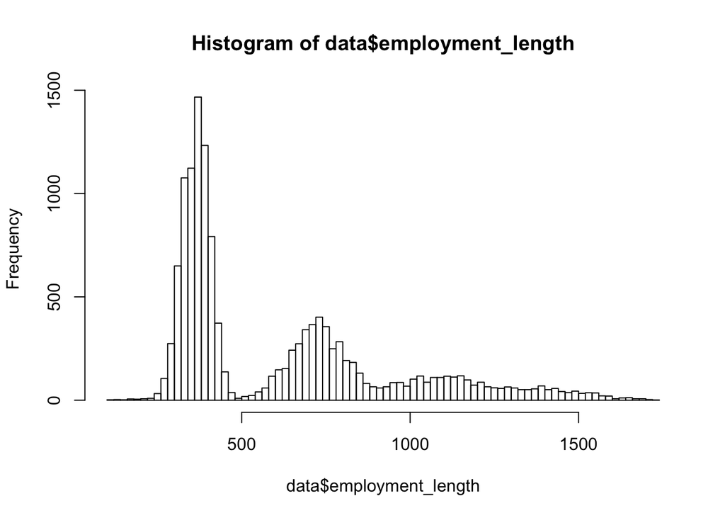

```r
#How many days were they employed? This should matter. People might get bored in the same place for too long
data$employment_length = as.numeric(data$quit_date - data$join_date)

#Let's plot employee length in days
hist(data$employment_length, breaks = 100)
```

Very interesting, there are peaks around each employee year anniversary!

Now, let’s see if we find the characteristics of people who quit early. Looking at the histogram of employment_length, it looks like we could define early quitters as those people who quit within 1 yr or so. So, let’s create two classes of users : quit within 13 months or not (if they haven’t been in the current company for at least 13 months, we remove them)

```r
#Create binary class
data = subset(data, data$join_date < as.Date("2015/12/13") - (365 + 31)) # only keep people who had time to age
data$early_quitter = as.factor(ifelse( is.na(data$quit_date) | as.numeric(data$quit_date - data$join_date) > 396, 0, 1))
```

Let’s now build a model. Here we can just care about: seniority, salary, dept and company. A simple decision tree is probably more than enough.

```r
tree = rpart(early_quitter ~ .,data[, c("company_id", "dept", "seniority", "early_quitter", "salary")],
             control = rpart.control(minbucket = 30, maxdepth = 3 , cp = 0.000001),
             parms = list(prior = c(0.5,0.5))
             )
#we are not too interested in predictive power, we are mainly using the tree as a descriptive stat tool.
tree
```

```
n= 19270

node), split, n, loss, yval, (yprob)
      * denotes terminal node

1) root 19270 9635.0000 0 (0.5000000 0.5000000)
  2) salary>=224500 2764  855.3351 0 (0.6528040 0.3471960) *
  3) salary< 224500 16506 8026.7840 1 (0.4776014 0.5223986)
    6) salary< 62500 2887 1249.7210 0 (0.5498859 0.4501141) *
    7) salary>=62500 13619 6500.0510 1 (0.4632968 0.5367032) *
```

Not very surprising! Salary is what matters the most. After all, it probably has within it information about the other variables too. That is, seniority, dept and company impact salary. So salary carries pretty much all the information available.

It is interesting though that, looking at the terminal nodes, the way the tree split is: If salary between 62500 and 224500, the employee has higher probability of being an early quitter, otherwise she doesn’t. That means that **people who make a lot of money and very little are not likely to quit** (“little money” by Silicon Valley standards).

By plotting the proportion of early quitters by salary percentile, this becomes quite clear:

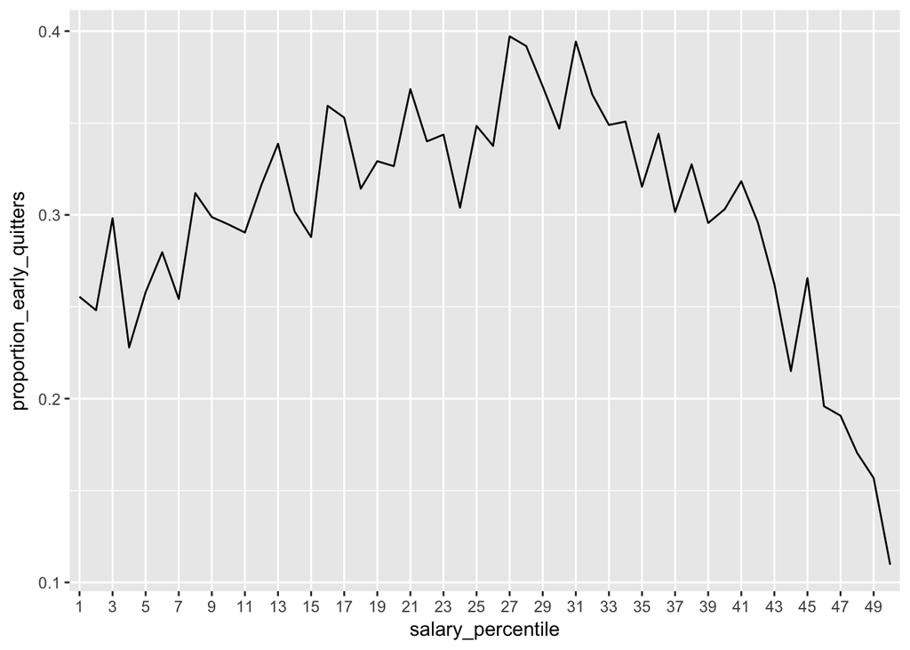

```r
data$salary_percentile = cut(data$salary, breaks = quantile(data$salary, probs = seq(0, 1, 0.02)),
                             include.lowest = TRUE, labels = 1:50)
data_proportion_by_percentile = data %>%
                                group_by(salary_percentile) %>%
                                summarize(proportion_early_quitters = length(early_quitter[early_quitter==1])/length(early_quitter)
                                          )
qplot(salary_percentile, proportion_early_quitters, data=data_proportion_by_percentile, geom="line", group =1) + scale_x_discrete(breaks = seq(1,50, by=2))
```

### Python

```python
import matplotlib.pyplot as plt

#How many days were they employed? This should matter. People might get bored in the same place for too long
data['employment_length'] = (data['quit_date'] - data['join_date']).astype('timedelta64[D]')

#Let's plot employment length in days
plt.hist(data['employment_length'].dropna(), bins=100)
plt.show()
```

[figure not shown]

Very interesting, there are peaks around each employee year anniversary!

Now, let’s see if we find the characteristics of people who quit early. Looking at the histogram of employment_length, it looks like we could define early quitters as those people who quit within 1 yr or so. So, let’s create two classes of users : quit within 13 months or not (if they haven’t been in the current company for at least 13 months, we remove them)

```python
from datetime import timedelta
#Create binary class
data=data[data['join_date'] <datetime.strptime("2015/12/13", "%Y/%m/%d") - timedelta(days=(365+31))]
data['early_quitter'] = np.where((data['employment_length']>396) | (np.isnan(data['employment_length'])), 0, 1)
```

Let’s now build a model. Here we can just care about: seniority, salary, dept, and company. A simple decision tree is probably more than enough.

```python
import graphviz
from sklearn.tree import DecisionTreeClassifier
from sklearn.tree import export_graphviz
from graphviz import Source

data_dummy = pandas.get_dummies(data[['company_id', 'dept', 'seniority', 'salary', 'early_quitter']], drop_first=True)

#we are not too interested in predictive power, we are mainly using the tree as a descriptive stat tool
tree = DecisionTreeClassifier( max_depth=4, min_samples_leaf = 30, class_weight="balanced", min_impurity_decrease = 0.001)
tree.fit(data_dummy.drop('early_quitter', axis=1), data['early_quitter'])

#visualize it
export_graphviz(tree, out_file="tree_employee.dot", feature_names=data_dummy.drop('early_quitter', axis=1).columns, proportion=True, rotate=True)
with open("tree_employee.dot") as f:
    dot_graph = f.read()
s = Source.from_file("tree_employee.dot")
s.view()
```

[figure not shown]

Not very surprising! Salary is what matters the most. After all, it probably has within it information about the other variables too. That is, seniority, dept and company impact salary. So salary carries pretty much all the information available.

It is interesting though that, looking at the terminal nodes, the way the tree split is: If salary between 224500 and 62500, the employee has higher probability of being an early quitter. That is, that’s a leaf that predicts class 1. Otherwise, the other two nodes predict class 0, which are >224500 and <62500. That means that **people who make a lot of money and very little are not likely to quit** (“little money” by Silicon Valley standards).

By plotting the proportion of early quitters by salary percentile, this becomes quite clear:

```python
#convert salary to its percentiles. We break it into 50 bins.
data['salary_percentile'] = pandas.qcut(data['salary'],q=50, labels=False)
#take proportion of early quitters for each percentile value and plot it
data.groupby('salary_percentile')['early_quitter'].mean().plot(title="Proportion of early quitters")
plt.show()
```

[figure not shown]

## Conclusions

1. Given how important is salary, I would definitely love to have as a variable the salary the employee who quit was offered in the next job. Otherwise, things like: promotions or raises received during the employee tenure would be interesting. Understanding the trajectory of someone via their salaries at different time points could be really useful.
2. Employees tend to quit at year anniversaries. Even if you don’t like your current job, you often stay for 1 yr before quitting + you often get stocks after 1 yr so it makes sense to wait.
3. Employees with low and high salaries are less likely to quit. Probably because employees with high salaries are happy there and employees with low salaries are not that marketable, so they have a harder time finding a new job. Obviously, those are totally different situations.
4. When building machine learning models on real data, you will find surprisingly often that one variable is way more important than the rest. We saw it in the conversion project too with number of pages visited. It is unlikely though that in real life one thing can explain complex phenomena. The most likely reason is that one variable is highly correlated with a lot of other variables. Like here, salary is obviously important, but especially because it is a proxy for so many other things (seniority, how marketable is someone, how much that person feels appreciated at work, etc). In these cases, assuming you have access to many other variables, try to get to the bottom of these relationships, by for instance building a model that predicts salary or removing salary and see which variables start to matter. After all, our model says that low salaries are less likely to quit. But definitely, it is not that if you reduce all salaries below 60K, retention will go up…

[Click here for a full course in product data science](https://course.datamasked.com)